# Quiz1대비(1)

김재현

2023-10-22

## R관련 2,3,4장, R4강

### sort vs rank vs order

```r
x= c(10, 15, 8, 22)
sort(x)
```

```
## [1]  8 10 15 22
```

sort = 벡터 내 원소를 오름차순 정리

```r
rank(x)
```

```
## [1] 2 3 1 4
```

rank = sort했을 경우 벡터 내 원소가 몇번째에 있을지 알려준다.

```r
order(x)
```

```
## [1] 3 1 2 4
```

order = sort한 상태의 벡터내 원소가 원래 몇번째였는지 알려준다.

*문제*

```r
order(c(12,5,9,20))
```

```
## [1] 2 3 1 4
```

*문제*

```r
1:5 + 1:2
```

```
## [1] 2 4 4 6 6
```

**위와 같이 길이가 맞지 않은 벡터를 계산할 때 recycle rule이 적용된다.**

rev = 순서를 반대로 바꾼다.

```r
rev(sort(c(2,7,3)))
```

```
## [1] 7 3 2
```

```r
rev(c(2,7,3))
```

```
## [1] 3 7 2
```

### Inf, NaN

R은 double precison 사용하여 Infinity까지 표현해준다.  
NaN Not a Number가 나오는 상황만 유의하자.

```r
3/0
```

```
## [1] Inf
```

```r
exp(-Inf)
```

```
## [1] 0
```

```r
(0:3)^Inf
```

```
## [1]   0   1 Inf Inf
```

```r
Inf-Inf
```

```
## [1] NaN
```

```r
Inf/Inf
```

```
## [1] NaN
```

*문제*

```r
0/0
```

```
## [1] NaN
```

```r
log(-1, base = 10)
```

```
## [1] NaN
```

*문제*

고객명단 %>% group_by（거주지역） %>% summarize（지역평균=mean（소득금액））

위 식은 어떤 의미인가?

답: 고객명단 데이터프레임에 있는 변수 중 거주지역 값 별로 소득금액의 평균값을 계산하여 지역평균 변수에 저장하라는의미

%>% 는 chain operator, pipe operator 이고, dplyr 패키지 사용시에 쓸 수 있다.

*예시*

```r
worms = read.table('worms.txt', header = T)
head(worms)
```

```
##        Field.Name Area Slope Vegetation Soil.pH  Damp Worm.density
## 1     Nashs.Field  3.6    11  Grassland     4.1 FALSE            4
## 2  Silwood.Bottom  5.1     2     Arable     5.2 FALSE            7
## 3   Nursery.Field  2.8     3  Grassland     4.3 FALSE            2
## 4     Rush.Meadow  2.4     5     Meadow     4.9  TRUE            5
## 5 Gunness.Thicket  3.8     0      Scrub     4.2 FALSE            6
## 6        Oak.Mead  3.1     2  Grassland     3.9 FALSE            2
```

```r
library(dplyr)
worms %>% group_by(Vegetation) %>% summarize(AreaM = mean(Area), SlopeM = mean(Slope))
```

```
## # A tibble: 5 × 3
##   Vegetation AreaM SlopeM
##   <chr>      <dbl>  <dbl>
## 1 Arable      3.87   1.33
## 2 Grassland   2.91   3.67
## 3 Meadow      3.47   1.67
## 4 Orchard     1.9    0
## 5 Scrub       2.42   7
```

worms 데이터베이스 내 데이터를 Vegetation 변수의 값으로 나눠서 Area의 평균값을 AreaM, Slope의 평균값을 SlopeM 변수에 저장한다.

### coplot

```r
Ozone = read.table('ozone.txt', header = T)
head(Ozone)
```

```
##   rad temp wind ozone
## 1 190   67  7.4    41
## 2 118   72  8.0    36
## 3 149   74 12.6    12
## 4 313   62 11.5    18
## 5 299   65  8.6    23
## 6  99   59 13.8    19
```

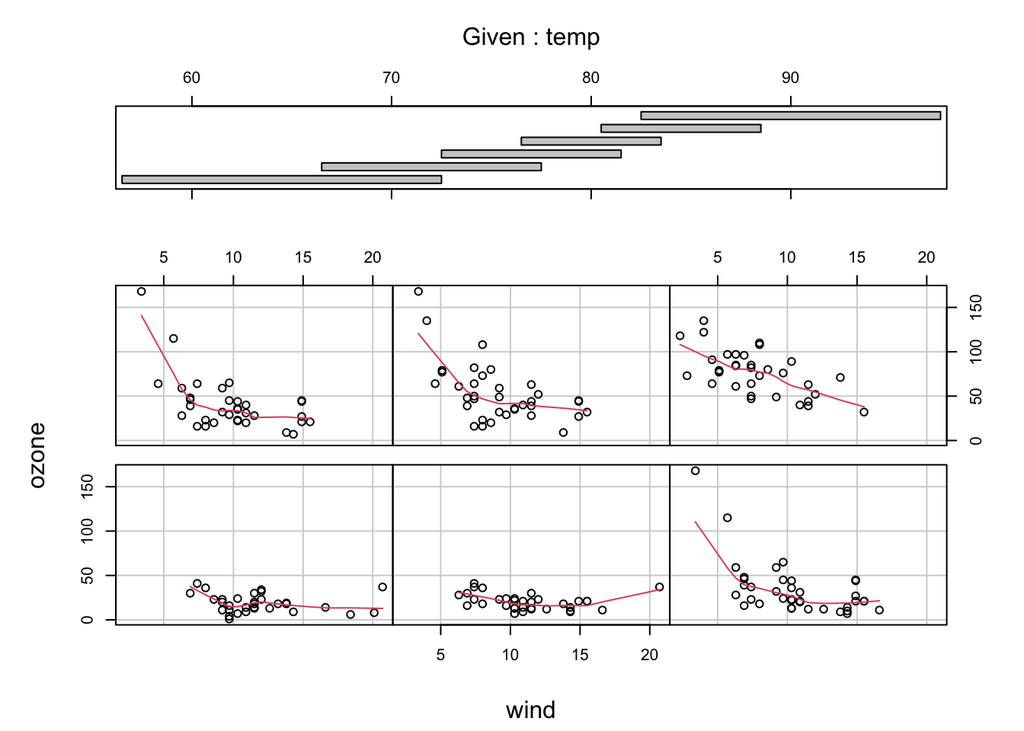

```r
coplot(ozone~wind|temp, Ozone, panel = panel.smooth)
```

```r
# figure margin too large는 Rstudio창 폭이 너무 작아서 생길 수 있음
```

temp를 6구간으로 나눠서 각 temp 하에 wind와 ozone의 관계를 plot해준다. ozone이 종속변수, wind가 독립변수.

*문제*

위 R코드 결과를 보고 해석하여라

**답**

1. 기온과 오존과는 **양의 상관관계**가 존재 (즉, 기온이 올라가면 오존의 양도 증가)  
   (조건부 변수(temp)와 종속변수(ozone)과의 관계 먼저 언급)
2. 하지만 **바람의 세기에 따라 이러한 양의 관계 정도가 매우 다르게 나타남.**(독립 변수에 의해 조건부변수와 종속변수의 관계가 달라진다는 점 언급.)  
   바람이 거의 없는 경우는 높은 기울기, 바람이 약간 있는 경우는 중간 정도의 기울기, 바람이 센 경우는 낮은 기울기의 관계를 가짐.
3. 이러한 경우 바람세기(wind)와 기온(temp)은 **상호작용효과**가 있다고 볼 수 있다. (또는 바람의 세기가 기온과 오존의 관계를 변화시켜주는 조절효과가 있다고 말한다.)

### qunatmod 패키지 getSymbols 함수

quantmod 패키지는 quantitative trader 즉, 퀀트(Quant)가 개발, 테스팅하는 과정을 보조하기 위해 만들어진 패키지다.  
getSymbols함수는 야후 파이낸스에서 시세를 받아온다.

### length 활용

*문제*  
1000개의 0에서 1사이 uniform random number를 생성하고 0.3보다 큰값의 비율을 계산하는 R코드를 작성하시오.

```r
x = runif(1000)
length(x[x > 0.3])/1000
```

```
## [1] 0.686
```

### quantile, ecdf 비교

```r
df1 = iris$Sepal.Length
head(df1)
```

```
## [1] 5.1 4.9 4.7 4.6 5.0 5.4
```

```r
Fn = ecdf(x = df1)
Fn(5)
```

```
## [1] 0.2133333
```

```r
quantile(x = df1,probs = 0.2133333)
```

```
## 21.33333%
##  5.078666
```

qunatile과 ecdf는 역함수 관계

### 조합 combination

n개의 원소를 갖는 집합에서 r개를 순서에 관계없이 뽑는 경우의수 *순열 permutaion은 순서를 생각하고 뽑는 경우의 수*

*문제*  
5C2의 값은?

```r
choose(n = 5, k = 2)
```

```
## [1] 10
```

```r
(5*4)/(2*1)
```

```
## [1] 10
```

5C2 , 5개중 2개를 순서에 관계없이 뽑는 경우의 수를 보여주는 함수도 있다.

```r
combn(5,2)
```

```
##      [,1] [,2] [,3] [,4] [,5] [,6] [,7] [,8] [,9] [,10]
## [1,]    1    1    1    1    2    2    2    3    3     4
## [2,]    2    3    4    5    3    4    5    4    5     5
```

### 연산자 순서

**%% 와 %/%**

```r
5 %% 2
```

```
## [1] 1
```

```r
5 %/% 2
```

```
## [1] 2
```

*예시*

```r
2 * 5 %% 3 == 4
```

```
## [1] TRUE
```

comment : * 보다 %% 가 우선

```r
2 * 3 ^ 4 %% 4 == 2
```

```
## [1] TRUE
```

comment : %% 보다 ^ 이 우선

```r
2 ^ 4 / 8 %/% 2 == 4
```

```
## [1] TRUE
```

^ -> %%, %/% -> *, / -> + , -

### runif 함수

uniform distribution (균등분포)를 이루는 랜덤값을 만들 수 있다.

```r
#make this example reproducible
set.seed(5)

#generate 10 random values from uniform distribution
runif(n=10, min=50, max=100)
```

```
##  [1] 60.01072 84.26093 95.84379 64.21997 55.23251 85.05287 76.39800 90.39676
##  [9] 97.82501 55.52265
```

출처 : https://www.statology.org/runif-in-r/

*min, max를 생략하면?*

```r
runif(10)
```

```
##  [1] 0.2732849 0.4905132 0.3184040 0.5591728 0.2625931 0.2018752 0.3875257
##  [8] 0.8878698 0.5549226 0.8421794
```

0과 1 사이에서 random variable 생성

*문제*

다음 R식의 결과가 어떠한 내용인지 설명하시오.

```r
as.integer(runif(100)*6+1)
```

```
##   [1] 6 5 2 2 1 3 3 6 1 6 3 1 2 1 1 3 4 4 3 3 5 2 5 4 6 4 5 1 5 4 3 4 6 6 6 3 2
##  [38] 2 2 1 4 2 6 6 6 6 6 1 6 5 5 5 1 6 1 6 1 5 3 2 6 5 2 1 3 1 6 5 2 4 5 3 2 3
##  [75] 2 5 2 4 3 3 6 5 4 6 6 3 2 4 3 2 2 4 5 2 3 3 3 1 4 2
```

위 R식은 1,2,3,4,5,6 중 랜덤으로 하나를 뽑는 과정을 100번 반복하는 시뮬레이션이다.  
즉 주사위를 100번 던지는 시뮬레이션과 동일하다.

Runif(100)은 0에서 1까지의 구간에서 숫자 100개를 랜덤으로 뽑는 random number generator이다. 0부터 1사이의 숫자에 6을 곱하면, 0에서 6 사이 값을 갖게 되고, 거기에 1을 더하므로 1에서 7 사이 값을 가지게 된다. 그 값에 as.integer()함수를 적용하여 정수부분만 택하게 되면 1,2,3,4,5,6 중 하나가 된다.

### for 함수

for 함수는 반복, loop에 사용한다.

```r
for (i in 1:10) {
  print(i)
}
```

```
## [1] 1
## [1] 2
## [1] 3
## [1] 4
## [1] 5
## [1] 6
## [1] 7
## [1] 8
## [1] 9
## [1] 10
```

```r
j <- k <- 0
for (i in 1:3) {j <- i-5; k <- k + i*j; print(i+j+k) }
```

```
## [1] -7
## [1] -11
## [1] -15
```

1번 print == j = -4, k = -4 , i = 1 현재 j와 k에는 -4 가 입력된 상태 2번 print == j = -3, k = -4 + -6 = -10 , i = 2 현재 j와 k에는 -3, -10이 입력된 상태 3번 print == j = -2, k = -10 + -6 = -16 , i = 3

### 인덱싱

인덱싱할 때 comma를 생략하면?

*데이터준비*

```r
titles <- c('Probability', 'Finance', 'Simulation')
authors <- c('Breiman', 'Lehmann', 'Givens')
years <- c(1968, 1983, 2005)
books <- data.frame(title=titles, author=authors, year=years)
head(books)
```

```
##         title  author year
## 1 Probability Breiman 1968
## 2     Finance Lehmann 1983
## 3  Simulation  Givens 2005
```

*문제*  
books[1:2] 와 books[1:2, ] 의 차이는?

```r
books[1:2]
```

```
##         title  author
## 1 Probability Breiman
## 2     Finance Lehmann
## 3  Simulation  Givens
```

**인덱싱할 때 comma를 생략하면 열을 선택한다.**

```r
books[2:3]
```

```
##    author year
## 1 Breiman 1968
## 2 Lehmann 1983
## 3  Givens 2005
```

```r
books[1:2, ]
```

```
##         title  author year
## 1 Probability Breiman 1968
## 2     Finance Lehmann 1983
```

*!=*

```r
x <- 10:15;
x
```

```
## [1] 10 11 12 13 14 15
```

```r
x[x != 12]
```

```
## [1] 10 11 13 14 15
```

!= 으로 원소를 제외하고 고를 수 있다.

```r
x[x != 10]
```

```
## [1] 11 12 13 14 15
```

*문제*  
score 라고 부르는 데이터프레임에 저장되어있는 자료 중에 성적이 70점 이상이고 성별이 여자인 경우를 따로 뽑아서 이름이 먼저 나오게 하고 그 다음 성적이 나오게 구성하라

```r
# 샘플 데이터 생성
library(tidyverse)
score = tibble('성적' = c(50,60,70,80,90,100),
               '성별' = c('남','남','남','여','여','여'),
               '이름' = c('갑순','갑돌','말자','말순','복자','복순'))
head(score)
```

```
## # A tibble: 6 × 3
##    성적 성별  이름
##   <dbl> <chr> <chr>
## 1    50 남    갑순
## 2    60 남    갑돌
## 3    70 남    말자
## 4    80 여    말순
## 5    90 여    복자
## 6   100 여    복순
```

```r
# 조건문 + 열 지정 인덱싱
score[score$성적>=70 & score$성별=='여',c('이름','성적')]
```

```
## # A tibble: 3 × 2
##   이름   성적
##   <chr> <dbl>
## 1 말순     80
## 2 복자     90
## 3 복순    100
```

*문제*

```r
x <- 10:15; x[rep(c(1,2),2)]
```

```
## [1] 10 11 10 11
```

### 상관계수 cor

두 변수간의 상관계수를 알고 싶은 경우 사용한다. default method는 pearson이다.

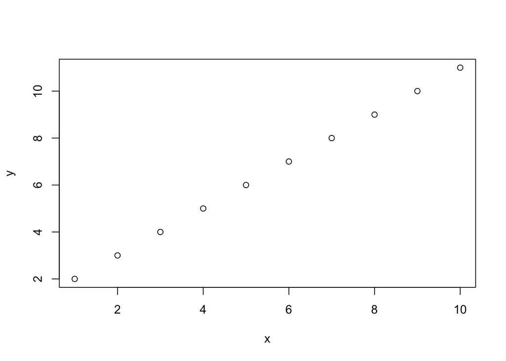

```r
x = c(1:10)
y = c(2:11)
plot(x,y)
```

```r
cor(x,y)
```

```
## [1] 1
```

### pnorm

**pnorm(quantile,mean,sd)**  
pnorm을 통해 어떤 mean, sd를 갖고 있는 정규분포에서 특정값의 누적확률을 구할 수 있다.

*문제*

평균이 100이고 표본편차가 10인 정규분포로 부터 100개의 표본을 뽑아 평균을 계산한 경우, 이 표본평균의 값이 105 이상 나타날 확률을 R 함수 식으로 표현 하시오.

```r
1-pnorm(105,100,1)
```

```
## [1] 2.866516e-07
```

**표본평균**의 평균에 대한 정규분포에서 특정값 이상이 나타날 확률을 구해야한다.  
그러므로 pnorm 함수에서 표준편차(standard deviation)가 아닌 표준오차(standard error)를 사용하도록 주의해야 한다.

*표준오차*  
표준오차 SE는 표본 통계량(statistics)의 표준편차(sd)다.  
표준오차는 표준편차를 sqrt(n)값(제곱근 square root)으로 나눈다.

아래 글 참고  
https://angeloyeo.github.io/2020/02/12/standard_error.html

### 사용자 정의함수 & rnorm

```r
tstat.2 <- function(x,y) {
n1 <- length(x)
n2 <- length(y)
numerator <- mean(x) - mean(y)
denominator <- sqrt(var(x)/n1 + var(y)/n2)
numerator/ denominator
}
```

**설명** function괄호 안의 x와 y는 tstat.2함수의 인수에 해당한다.  
x와 y값에 따라, 결과값이 달라질 것이다.  
tstat.2 함수를 사용할 때에는 항상 tstat.2(a,b) 와 같이 인수에 값을 넣어줘야 한다.

function 중괄호 사이에는 함수를 실행할 때 작동하는 코드가 들어간다.  
함수 안에 있는 코드를 함수의 본체라고 한다.  
이 본체 마지막 줄에는 결과를 보여주는 코드가 반드시 들어가야 한다.

numerator에는 x와 y객체의 평균값 차이가 들어간다. numerator는 한글로 ’분자’이다.  
denominator에는 각 객체의 분산을 객체 길이로 나누고 더한 다음 square root한 값이다.

위 함수로 두 객체의 t검정을 할 수 있다.

```r
Sample.1 <- rnorm(140,0.2)
Sample.2 <- rnorm(160, 1, 2)
tstat.2 (Sample.1, Sample.2)
```

```
## [1] -3.769722
```

rnorm(n,mean,sd)을 이용하여 정해진 평균과 표준편차를 가지며, 정규분포를 갖는, n개의 관측치를 만들어낼 수 있다.

mean, sd 인수의 default 값은 각각 0, 1 이다.

*문제*

1부터 n까지 짝수만 더하는 R함수 EvenSum(n)을 만들어보시오

```r
EvenSum <- function(n) {
  if (n < 2) {
    # Base case: If n is less than 2, there are no even numbers to sum.
    return(0)
  } else {
    # Use the sum function with a sequence of even numbers from 2 to n.
    even_numbers <- seq(from = 2, to = n, by = 2)
    result <- sum(even_numbers)
    return(result)
  }
}

EvenSum(5)
```

```
## [1] 6
```

### polygon, seq , dnorm, plot 함수(type인수)

**간단한 polygon 함수 설명** https://oooo12.tistory.com/16

*문제*  
다음의 R 코드는 표준정규분포의 확률밀도함수를 그리고 -1보다 작은 영역에 색을 칠하는 그래프이다. (가) 문장과 (나) 문장의 차이에 따른 결과의 차이에 대하여 설명하여라

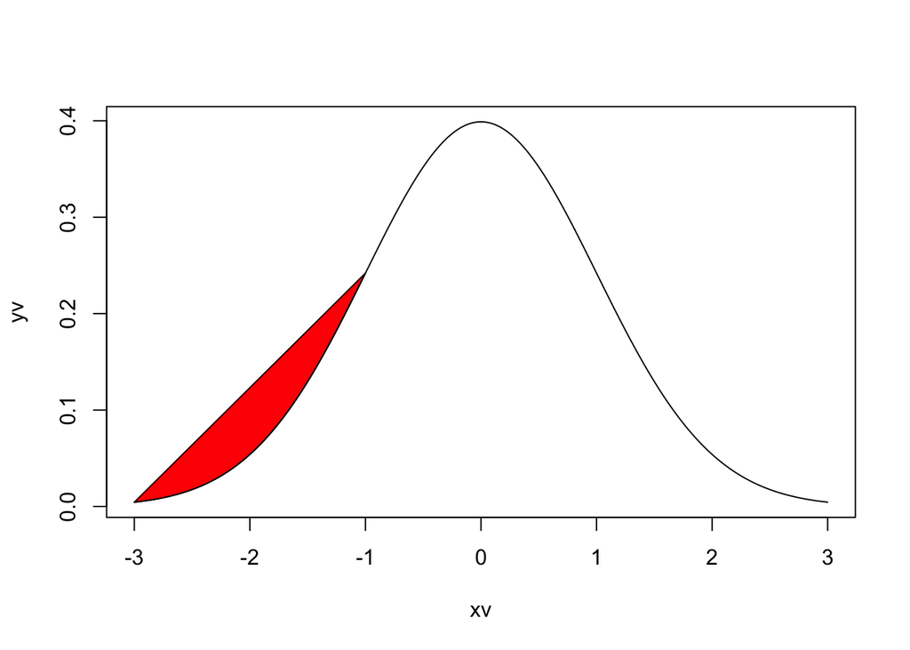

```r
xv <- seq(-3,3,0.01) # -3 ~ 3까지 0.01 간격의 벡터
yv <- dnorm(xv)
plot(xv,yv,type = 'l')
#(가)
polygon(c(xv[xv<=-1]),c(yv[xv<=-1]),col="red")
```

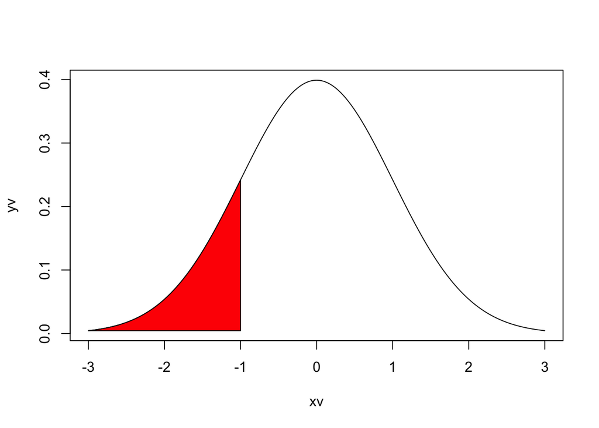

```r
plot(xv,yv,type = 'l')
#(나)
polygon(c(xv[xv<=-1],-1),c(yv[xv<=-1],yv[xv==-3]) ,col="red")
```

*문제*

```r
seq(length=3, from=-10, to=10)
```

```
## [1] -10   0  10
```

seq함수에서 length 인수를 사용하면 length 에 맞춰서 벡터 내 원소 숫자를 결정한다. 원소는 동일한 간격을 갖도록 한다.

### matrix함수와 nrow 인수 (+ rep함수)

```r
matrix( rep ( c ( 1:3,5 ) , 2 ) , nrow=2)
```

```
##      [,1] [,2] [,3] [,4]
## [1,]    1    3    1    3
## [2,]    2    5    2    5
```

### star plot

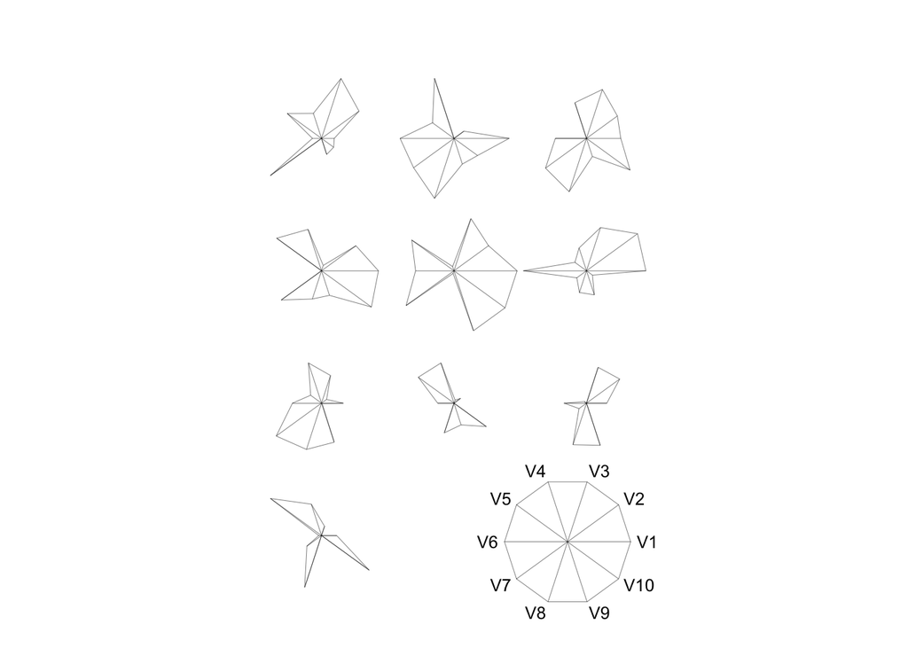

```r
stars(as.data.frame(matrix(runif(100), nrow=10, byrow=TRUE)), key.loc= c(6,2))
```

star plot은 spider, radar plot 으로 불리기도 한다.  
많은 변수에 대한 다이어그램을 한 곳에 그려낼 수 있는 plot이다. 위 plot에서 10개 관측치의 10개 변수에 대한 도표를 그려낸 것을 볼 수 있다.

### ceiling

*문제*

어떤 실수 값보다 큰 최소의 정수값을 제공하는 R의 함수는 무엇인가? (예, 12.2-> 13)

```r
ceiling(12.2)
```

```
## [1] 13
```

**round와의 차이**

```r
round(12.2)
```

```
## [1] 12
```

```r
round(11.6)
```

```
## [1] 12
```

**floor**

```r
floor(12.2)
```

```
## [1] 12
```

```r
floor(11.6)
```

```
## [1] 11
```

ceiling = 올림  
round = 반올림  
floor = 내림

### 모자이크 plot

*문제*

1973년, 미국 연방정부는 버클리 캘리포니아 주립대학교(Universiy of California, Berkeley)가 대학원 입학과정에서 성차별이 이루어졌다고 고발하였다. 이에 대한 자료은 ‘berkely.csv’ 파일에 저장되어 있다. 이 파일에 저장된 변수는 다음과 같다.

Admit: 입학허가상태 (Admitted/Rejected)  
Gender: 성별 (Male/Female)  
Dept: 6개 주요 학과 (A,B, C, D, E, F)  
Freq: 빈도수

다음 mosaic 그림을 보고 A학과에 대한 특징을 설명하시오.

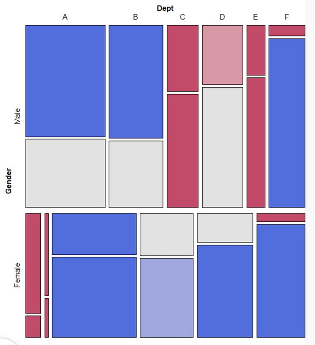

**답**

1. A학과에는 다른 학과와 비교하여 입학률이 매우 높다. (또는 거절률이 매우 낮다)
2. A학과의 경우, 대부분의 지원자가 남학생이며, 여학생의 지원 비율이 매우 낮다.
3. A학과 여학생의 입학률이 남학생 입학률보다 높다.

### lapply, list

list함수는 list class를 갖는 객체를 만드는데 사용한다.

```r
x <- list(a = 1:10, beta = exp(-3:3), logic = c(TRUE, FALSE, FALSE, TRUE))
x
```

```
## $a
##  [1]  1  2  3  4  5  6  7  8  9 10
##
## $beta
## [1]  0.04978707  0.13533528  0.36787944  1.00000000  2.71828183  7.38905610
## [7] 20.08553692
##
## $logic
## [1]  TRUE FALSE FALSE  TRUE
```

```r
lapply(x, mean)$a
```

```
## [1] 5.5
```

lapply(x,FUN)는 x의 모든 변수에 FUN을 적용시켜 리스트를 반환한다. 위 코드에서 $a가 없다면 beta, logic에 대해서도 mean함수(FUN인수에 해당)를 적용시켜서 반환할 것이다.

```r
lapply(x,mean)
```

```
## $a
## [1] 5.5
##
## $beta
## [1] 4.535125
##
## $logic
## [1] 0.5
```